# What Factors Affect Chocolate Ratings?

## by Abbie Weisenbloom

## Investigation Overview

Are you having a craving for chocolate? I found a really interesting bar that has no sugar, a nice chemical overtone with a touch of salt and finishing with "wft" flavor in this dataset. Or perhaps you prefer one that is creamy and sweet with a hint of floral notes and a sandy finish? Let's check out how features of the chocolates in this dataset correlate with how they are rated!

## Dataset Overview

There are 2224 chocolate bars in the dataset with 20 features (rating, company, company location, review date,country of bean origin, specific bean origin or bar name, cocoa percent, counts of ingredients, beans, cocoa_butter, vanilla, lecithin, salt, sugar, sweetener without sugar, first taste, second taste, third taste, and fourth taste). It took me awhile to orient myself with all of the ways to explore this data, so I focused on the chocolate bar tastes, ingredients, and bean of origin.

All of the chocolate bars in this dataset are 55% cocoa and above, which means they are various intensities of dark chocolate.

## Distribution of Chocolate Bar Ratings

Although they are numeric, the chocolate bar ratings fall into fairly discrete groupings with 3.0 and 3.5 being the most popular ratings. You can see a slight bimodal shape.

4.0 - 5.0 = Outstanding  
3.5 - 3.9 = Highly Recommended  
3.0 - 3.49 = Recommended  
2.0 - 2.9 = Disappointing  
1.0 - 1.9 = Unpleasant

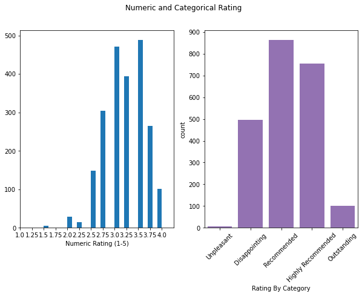

```python
fig, ax = plt.subplots(ncols = 2, figsize = [10,6])

plt.subplot(1, 2, 1)
binsize = 0.10
bins = np.arange(0, choc['rating'].max()+binsize, binsize)
#plt.figure(figsize=[8, 5])
plt.hist(data = choc, x = 'rating', bins = bins)
plt.xlim([1.0,4.25])
plt.xticks(np.arange(1.0,4.25,0.25), np.arange(1.0,4.2,0.25))
plt.xlabel('Numeric Rating (1-5)')

plt.subplot(1, 2, 2)
base_color = sb.color_palette()[4]
plt.xticks(rotation = 45)
plt.yticks(np.arange(0,1000,100), np.arange(0,1000,100))
bins = np.arange(0, 2000, 100) #this way bins are the same size
sb.countplot(data = choc, x = "rating_category", color = base_color )
plt.xlabel('Rating By Category')

fig.suptitle('Numeric and Categorical Rating')

plt.show()
```

## Distribution of Ingredients

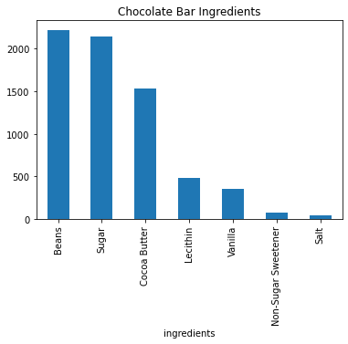

```python
#choc2 will have ingredients in 0 /1 for making numeric calculations.
choc2 = choc.copy()
def rating(row,not_item):
    if row == not_item:
      return 0
    else:
      return 1
def bool_convert(col,not_item):
    choc2[col] = choc2[col].apply(lambda row: rating(row,not_item))
def convert(col_dict):
    for key,value in col_dict.items():
        bool_convert(key,value)
#convert these columns to integer values
cols_to_convert = {'beans':'have_not_bean',
        'sugar':'have_not_sugar',
        'cocoa_butter': 'have_not_cocoa_butter',
        'vanilla':'have_not_vanila',
        'lecithin':'have_not_lecithin',
        'salt':'have_not_salt',
        'sweetener_without_sugar':'have_not_sweetener_without_sugar'}

convert(cols_to_convert)
#convert to integer
ingred = ["beans","cocoa_butter", "vanilla","lecithin","salt","sugar","sweetener_without_sugar"]
for i in ingred:
    choc2[i] = choc2[i].astype(int)

# Use melt to combine all ingredients into a single column
ingredients = choc2.melt(id_vars = ['specific_bean_origin_or_bar_name','rating'],
                                     value_vars = ['beans','cocoa_butter', 'vanilla', 'lecithin','salt','sugar','sweetener_without_sugar'], var_name = 'ingredients', value_name = 'contains').dropna()

total_ingred = ingredients.groupby('ingredients').sum().reset_index()
total_ingred.sort_values(by=['contains'], ascending=False, inplace=True)
#plot graph
plt.figure(figsize = [15, 15]);
ax = total_ingred.plot.bar(x='ingredients', y='contains', legend=None,rot=0)
locs, labels = plt.xticks()
plt.title('Chocolate Bar Ingredients')
plt.xticks(locs, ['Beans','Sugar','Cocoa Butter', 'Lecithin', 'Vanilla','Non-Sugar Sweetener', 'Salt'])
plt.xticks(locs,labels)
plt.xticks(rotation = 90);
```

## Ingredients

This scatterplot showing all of the ingredients represented in the dataset is a little harder to interpret, however, it gives an interesting view of the ingredient / rating relationship.

- **At the top right**, we see that most highly-rated chocolates have beans, sugar, and cocoa butter, and less frequently lecithin, vanilla, and sweetener without sugar.
- **At the top left**, we see that more lower-rated chocolates contain vanilla, sugar, and lecithin.

However, since we don't have the data for the percentage of each ingredient per bar we cannot tell what the magic proportion of secret ingredient is that contributes to these ratings. However we can dig a little further to see how flavor notes contribute to the ratings as well as the country of bean origin.

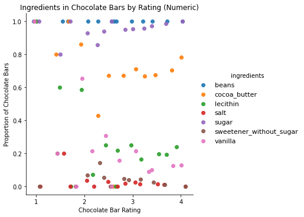

```python
ing_rating_mean = ingredients.groupby(['ingredients','rating']).mean().reset_index()
ing_rating_mean.tail(50);
plt.figure(figsize = [10,10]);

g = sb.FacetGrid(data = ing_rating_mean, hue = 'ingredients', height = 5);

g = g.map(sb.regplot, 'rating','contains', x_jitter = 0.1, fit_reg = False, scatter_kws={'alpha':0.90});
x_ticks = [1,2,3,4];
g.set(xticks = x_ticks, xticklabels = x_ticks);
plt.xlabel('Chocolate Bar Rating')
plt.ylabel('Proportion of Chocolate Bars')

plt.title('Ingredients in Chocolate Bars by Rating (Numeric)')
g.add_legend(fontsize = 11);
plt.show();
```

## First, Second, Third Tastes Distribution

What are the first, second, and third taste flavors that you notice when you sample chocolate? Here we see what the distribution is for the first three flavor notes in our dataset as recorded by the reviewers. In the following slide, we'll see which flavor notes contribute to the highest ratings of chocolate.

Do some of these tastes remind you of any delicious dark chocolate that you may have experienced? Of course, I'm making a big assumption that you enjoy dark chocolate!

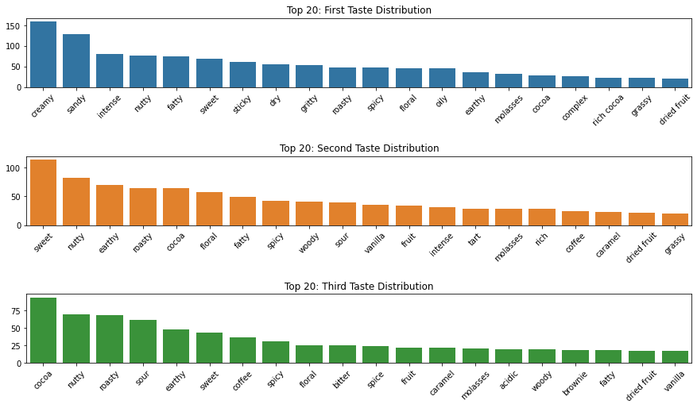

```python
#top 20 first,second, third taste distributions

fig, ax = plt.subplots(nrows=3, figsize = [15,8]);

#first taste
sb.barplot(x=choc.first_taste.value_counts()[:20].index,
           y=choc.first_taste.value_counts()[:20].values,
           color = sb.color_palette()[0],
           ax = ax[0]), ax[0].tick_params(axis='x', rotation=45)

#second taste
sb.barplot(x=choc.second_taste.value_counts()[:20].index,
           y=choc.second_taste.value_counts()[:20].values,
           color = sb.color_palette()[1],
           ax = ax[1]), ax[1].tick_params(axis='x', rotation=45)
;
#third taste
sb.barplot(x=choc.third_taste.value_counts()[:20].index,
           y=choc.third_taste.value_counts()[:20].values,
           color = sb.color_palette()[2],
           ax = ax[2]),ax[2].tick_params(axis='x', rotation=45)

ax[0].set_title('Top 20: First Taste Distribution')
ax[1].set_title('Top 20: Second Taste Distribution')
ax[2].set_title('Top 20: Third Taste Distribution')
plt.subplots_adjust(hspace = 1)
```

## Rating Categories vs. First, Second, & Third Tastes

This chart brings together the 5 chocolate rating categories, with the top 20 first, second, and third tastes. (Apologies! : The 5 charts on this page do not seem to all fit on the page using nbconvert. They are best seen in the notebook.) In this busy chart, we can see some interesting trends. For the Outstanding category, the creamy first taste dominates, followed by the intense taste. The second taste in this category has a lot of nutty, cocoa, spicy characteristics. The third taste has high levels of nutty, cocoa, coffee, and smoke.

The next category - Highly-Recommended - has more variety in taste ratings, but is still dominated by creamy, nutty, cocoa, and roasty overtones.

As we visually scan through the Highly-Recommended, Recommended, and Disappointing categories, we see a larger variety of competing tastes. The Recommended category is dominated by a sandy taste, which I don't associate with a pleasant creamy mouthfeel. Sandy is also highly correlated with the Disappointing Category, so its correlation with Recommended (as well as my personal bias) makes it a non-intuitive characteristic that we could follow up on.

The Unpleasant Category has few tastes but they *seem* unpleasant -- klingy, acidic, chemical, very bitter, unpleasant, and the classic taste, 'wtf'.

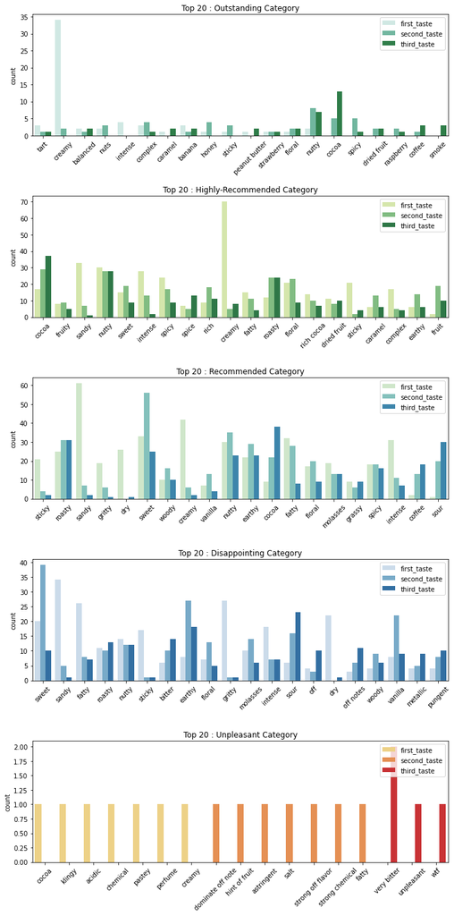

```python
#move all tastes into single column for analysis
tastes = choc.melt(id_vars = ['specific_bean_origin_or_bar_name','rating_category','rating'],
                                     value_vars = ['first_taste','second_taste','third_taste'], var_name = 'tastes', value_name = 'contains').dropna()

outstanding = tastes.loc[tastes['rating_category'] == "Outstanding"]
top_outstanding = (outstanding[np.isin(outstanding['contains'],(outstanding['contains'].value_counts(sort=True).nlargest(20)).index)])

highly_rec = tastes.loc[tastes['rating_category'] == "Highly Recommended"]
top_highly_rec = (highly_rec[np.isin(highly_rec['contains'],(highly_rec['contains'].value_counts(sort=True).nlargest(20)).index)])

recommended = tastes.loc[tastes['rating_category'] == "Recommended"]
top_recommended = (recommended[np.isin(recommended['contains'],(recommended['contains'].value_counts(sort=True).nlargest(20)).index)])

disappointing = tastes.loc[tastes['rating_category'] == "Disappointing"]
top_disappointing = (disappointing[np.isin(disappointing['contains'],(disappointing['contains'].value_counts(sort=True).nlargest(20)).index)])

#get data for tastes in rating categories
unpleasant = tastes.loc[tastes['rating_category'] == "Unpleasant"]
top_unpleasant = (unpleasant[np.isin(unpleasant['contains'],(unpleasant['contains'].value_counts(sort=True).nlargest(20)).index)])

#plot rating categories, taste categories, tastes
plt.figure(figsize = [10, 20])

#order =top_20_tastes.contains.value_counts().index

# subplot 1: Outstanding
ax = plt.subplot(5, 1, 1)
sb.countplot(data = top_outstanding, x = 'contains', hue = 'tastes', palette = 'BuGn')
plt.legend(loc='upper right')
plt.title('Top 20 : Outstanding Category')
plt.xticks(rotation = 45)
plt.xlabel('')

# subplot 2: Highly-Recommended
ax = plt.subplot(5, 1, 2)
sb.countplot(data = top_highly_rec, x = 'contains', hue = 'tastes', palette = 'YlGn')
plt.legend(loc='upper right')
plt.title('Top 20 : Highly-Recommended Category')
plt.xticks(rotation = 45)
plt.xlabel('')

# subplot 3: Recommended
ax = plt.subplot(5, 1, 3)
sb.countplot(data = top_recommended, x = 'contains', hue = 'tastes', palette = 'GnBu')
plt.legend(loc='upper right')
plt.title('Top 20 : Recommended Category')
plt.xticks(rotation = 45)
plt.xlabel('')

# subplot 4: Disappointing
plt.subplot(5, 1, 4);
sb.countplot(data = top_disappointing, x = 'contains', hue = 'tastes', palette = 'Blues')
plt.legend(loc='upper right')
plt.title('Top 20 : Disappointing Category')
plt.xticks(rotation = 45)
plt.xlabel('')

# subplot 5: Unpleasant
plt.subplot(5, 1, 5);
sb.countplot(data = top_unpleasant, x = 'contains', hue = 'tastes', palette = 'YlOrRd' )
plt.legend(loc='upper right')
plt.xticks(rotation = 45)
plt.title('Top 20 : Unpleasant Category')
plt.xlabel('')

plt.tight_layout()
plt.subplots_adjust(hspace = .5)
```

## Top Country of Bean Origin

Lastly, let's see where the top-rated beans, which are after all the most important ingredient in chocolate, come from! I was surprised to see The United States on this list because I never considered it to be a chocolate producer; however, it turns out that Hawaii has the perfect climate for growing chocolate.

```
[(2.7, 3.6)]
```

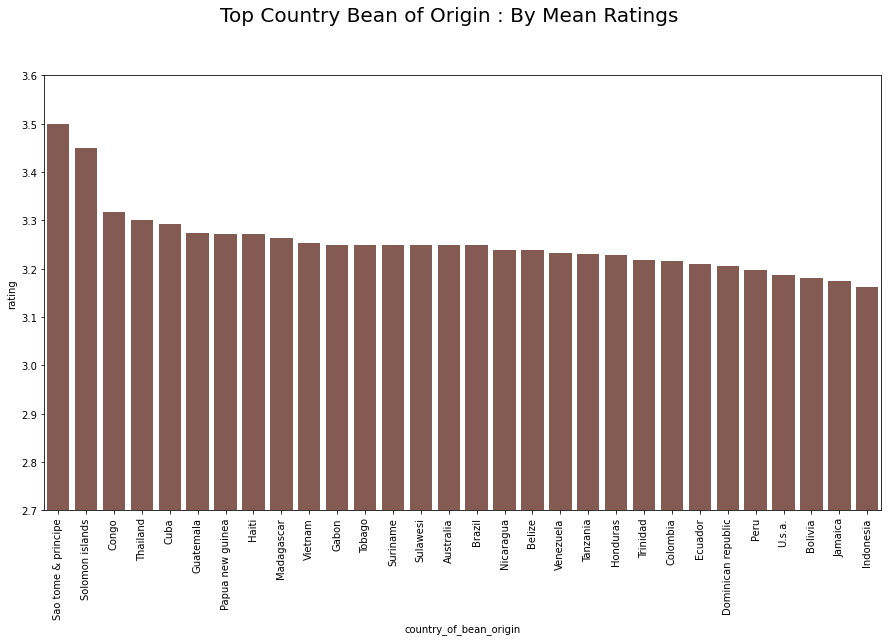

```python
#get mean rating by country_of_bean_origin
country_bean = choc.groupby(['country_of_bean_origin'])['rating'].mean().reset_index().sort_values(by='rating', ascending=False)
country_bean;
#plot
fig, ax = plt.subplots(figsize = [15,8]);
plt.suptitle('Top Country Bean of Origin : By Mean Ratings', fontsize=20,y=1);

#country bean_of_bean_origin (top 30)
g = sb.barplot(data = country_bean[:30],
           x='country_of_bean_origin',
           y='rating',
           color = sb.color_palette()[5],
           ax = ax);
ax.tick_params(axis='x', rotation=90)
g.set(ylim=(2.7, 3.6))
```

## Fun Facts:

The country of bean origin with the highest rated average bar, had only 1 bar in this data set but still had the highest average rating in spite of other countries that produced some higher-rated beans. This is the : Sao Tome & Principe bar made by French company Pralus. 75% Cocoa. 3.5 Rating. Tasting of deep cocoa, fatty, and mild ashey. Highly recommended.

The lowest rated chocolate bar in this dataset (rating: 1.0) was by Belgian company Neuhaus (Callebaut), from a blend of beans that tasted pastey with a strong off flavor. Unpleasant. Reviewed in 2007.